# dci_reimbursements_mortality_analysis

Harper Wallace

8/1/2020

#### 0. Read in raw economic data

```r
economic_descriptors_2000_raw <- read.csv("_csv/2000_DCI.csv", header=TRUE)
economic_descriptors_2017_raw <- read.csv("_csv/2017_DCI.csv", header=TRUE)
crosswalk_raw <- read.csv("_csv/zip_hsa_crosswalk.csv", header=TRUE)
```

Select just the ~`Zipcode` and ~`HSA` columns from the crosswalk, and give them better names:

```r
crosswalk <- crosswalk_raw %>% select(zipcode18, hsanum)
colnames(crosswalk)[1] <- "Zipcode"
colnames(crosswalk)[2] <- "HSA"
```

Make zip-wise economic data HSA-wise by adding new column `HSA` using `crosswalk` (`left_join` because there are more zip codes in crosswalk than there are in economic_descriptors_…), and clean up the table:

```r
economic_descriptors_2000_temp <- left_join(economic_descriptors_2000_raw, crosswalk, by="Zipcode")

# reorder columns so "HSA" comes after "Zipcode"
colorder_2000 <- c("Zipcode","HSA",colnames(economic_descriptors_2000_raw)[-c(1)])
economic_descriptors_2000_zip_hsa <- economic_descriptors_2000_temp[,colorder_2000]

# repeat for 2017
economic_descriptors_2017_temp <- left_join(economic_descriptors_2017_raw, crosswalk, by="Zipcode")
colorder_2017 <- c("Zipcode","HSA",colnames(economic_descriptors_2017_raw)[-c(1)])
economic_descriptors_2017_zip_hsa <- economic_descriptors_2017_temp[,colorder_2017]
```

#### 1. Aggregate economic data from 2000 and 2017 to HSA-level, tidy, compute changes, quintilize by DCI change

Create new summary data.frame of raw economic data aggregated by `HSA`, weighting appropriate descriptors by population.

```r
# .groups = 'drop' just suppresses a friendly message
economic_descriptors_2000 <- economic_descriptors_2000_zip_hsa %>%
  group_by(HSA) %>%
  summarise(Total.Pop.2000                                = sum(Total.Population.2000),
            DCI.2000                                      = weighted.mean(X2000.Distress.Score, Total.Population.2000),
            X.Adults.w.o.High.School.Degree.2000          = weighted.mean(X..of.Adults.w.o.a.High.School.Degree, Total.Population.2000),
            Poverty.Rate.2000                             = weighted.mean(Poverty.Rate, Total.Population.2000),
            X.Prime.Age.Adults.Not.in.Work.2000           = weighted.mean(X..of.Prime.Age.Adults.Not.in.Work, Total.Population.2000),
            Vacancy.Rate.2000                             = weighted.mean(Vacancy.Rate, Total.Population.2000),
            X.Non.Hispanic.White.2000                     = weighted.mean(Non.Hispanic.White...of.Population, Total.Population.2000),
            X.Hispanic.or.Latino.2000                     = weighted.mean(Hispanic.or.Latino.Share...of.Population, Total.Population.2000),
            X.Black.or.African.American.2000              = weighted.mean(Black.or.African.American...of.Population, Total.Population.2000),
            X.American.Indian.or.Alaska.Native.2000       = weighted.mean(American.Indian.or.Alaska.Native...of.Population, Total.Population.2000),
            X.Asian.or.Pacific.Islander.2000              = weighted.mean(Asian.or.Pacific.Islander...of.Population, Total.Population.2000),
            # MI17.X.25.Plus.w.Bachelors.or.Higher.2000     = weighted.mean(X..of.25..Population.w..a.Bachelors.Degree.or.Higher, Total.Population.2000),
            # MI17.X.25.Plus.w.Advanced.Degree.2000         = weighted.mean(X..of.25..Population.w..an.Advanced.Degree, Total.Population.2000),
            # MI17.X.Households.Receiving.Public.Assistance.Income.2000 = weighted.mean(X..of.Households.Receiving.Public.Assistance.Income, Total.Population.2000),
            # MI17.X.Enrolled.in.College.2000               = weighted.mean(X..Enrolled.in.College, Total.Population.2000),
            # MI17.X.18.Plus.in.Armed.Forces.2000           = weighted.mean(X..Population.18..in.Armed.Forces, Total.Population.2000),
            # MI17.X.in.Group.Quarters.2000                 = weighted.mean(X..Population.in.Group.Quarters, Total.Population.2000),
            .groups = 'drop'
            )

# repeat for 2017
economic_descriptors_2017 <- economic_descriptors_2017_zip_hsa %>%
  group_by(HSA) %>%
  summarise(Total.Pop.2017                           = sum(Total.Population),
            DCI.2017                                 = weighted.mean(Distress.Score, Total.Population),
            X.Adults.w.o.High.School.Degree.2017     = weighted.mean(X..of.Adults.w.o.a.High.School.Diploma, Total.Population),
            Poverty.Rate.2017                        = weighted.mean(Poverty.Rate, Total.Population),
            X.Prime.Age.Adults.Not.in.Work.2017      = weighted.mean(X..of.Prime.Age.Adults.Not.in.Work, Total.Population),
            Vacancy.Rate.2017                        = weighted.mean(Housing.Vacancy.Rate, Total.Population),
            X.Non.Hispanic.White.2017                = weighted.mean(Non.Hispanic.White...of.Population, Total.Population),
            X.Hispanic.or.Latino.2017                = weighted.mean(Hispanic.or.Latino.Share...of.Population, Total.Population),
            X.Black.or.African.American.2017         = weighted.mean(Black.or.African.American...of.Population, Total.Population),
            X.American.Indian.or.Alaska.Native.2017  = weighted.mean(American.Indian.or.Alaska.Native...of.Population, Total.Population),
            X.Asian.or.Pacific.Islander.2017         = weighted.mean(Asian.or.Pacific.Islander...of.Population, Total.Population),
            # MI00.X.Other.Race.2017                   = weighted.mean(Other.Race...of.Population, Total.Population),
            # MI00.X.Two.Plus.Races.2017               = weighted.mean(Two.or.More.Races...of.Population, Total.Population),
            # MI00.X.Foreign.Born.2017                 = weighted.mean(X..of.the.Population.Foreign.Born, Total.Population),
            .groups = 'drop'
            )
```

Subselect only `Total Population` and `DCI Score` columns to make truncated data.frames:

```r
dci_2000_trunc <- economic_descriptors_2000 %>%
  select(HSA, Total.Pop.2000, DCI.2000)

dci_2017_trunc <- economic_descriptors_2017 %>%
  select(HSA, Total.Pop.2017, DCI.2017)
```

### 2. Read in and tidy raw medicare reimbursements data, using HSA quintile rankings based on DCI changes

```r
reimb <- data.frame()
for (year in 2003:2015) {
  temp_table <- read.csv(paste("_csv/_reimb/", year, "_pa_reimb_table_hsa.csv", sep=""), header=TRUE)
  temp_table <- abs(temp_table[c(1,4,5)])
  colnames(temp_table) <- c("HSA", "Enrollees", "PASR.Total.Reimb.per.Enrollee")

  # years where raw data gives only 20% sample
  if (year >= 2003 & year < 2010) {
    temp_table$Enrollees = 5*temp_table$Enrollees
  }

  # compute total reimbursements as reimbursements per enrollee times enrollees
  temp_table <- temp_table %>%
    mutate(PASR.Total.Reimb = Enrollees * PASR.Total.Reimb.per.Enrollee)

  colnames(temp_table) <- c("HSA", paste(c("Enrollees.Reimb.", "PASR.Reimb.per.Enrollee.", "PASR.Total.Reimb."), year, sep=""))

  if (year == 2003) {
    reimb <- temp_table
  } else {
    reimb <- inner_join(reimb, temp_table, by="HSA")
  }
}

# remove incomplete cases while annual values are still organized in columns, to make sure each HSA has figures for each year
reimb <- reimb[complete.cases(reimb),]
```

### 3. Read in and tidy raw medicare mortality data, using HSA quintile rankings based on DCI changes

```r
mortality <- data.frame()
for (year in 2003:2015) {
  temp_table <- read.csv(paste("_csv/_mortality/", year, "_mortality_hsa.csv", sep=""), header=TRUE)
  temp_table <- abs(temp_table[c(1,3,4,5)])
  colnames(temp_table) <- c("HSA", paste("Enrollees.Mortality.", year, sep=""), paste("ASR.Total.Mortality.", year, sep=""), paste("ASR.Non.HMO.Mortality.", year, sep=""))
  if (year == 2003) {
    mortality <- temp_table
  } else {
    mortality <- inner_join(mortality, temp_table, by="HSA")
  }
}

# remove incomplete cases while annual mortalities are still arranged in columns, so each HSA has mortalities for each year
mortality <- mortality[complete.cases(mortality),]
```

```r
medicare_merged <- inner_join(reimb, mortality, by="HSA")
medicare_merged %>% summarise(n = n())
```

```
##      n
## 1 3226
```

Compute (in new data.frame) percent change in population, absolute change in population, initial (2000) and final (2017) DCI quintiles, absolute change in DCI, and percentile, pure-quintile, and more meaningful-quintile (limits defined to make group sizes approximately equal) change in DCI. Meaningful quintile scores (in `D.DCI.Mod.Quintile`) are, for $\Delta \text{DCI} = \text{DCI}_{2017} - \text{DCI}_{2000}$:

| Quintile | Definition | Description |
| --- | --- | --- |
| 1 | $\Delta \text{DCI} <= -15$ | “Large decrease in DCI” |
| 2 | $-15 < \Delta \text{DCI} <= -5$ | “Small decrease in DCI” |
| 3 | $-5 < \Delta \text{DCI} <= 5$ | “No change in DCI” |
| 4 | $5 < \Delta \text{DCI} <= 15$ | “Small increase in DCI” |
| 5 | $15 < \Delta \text{DCI}$ | “Large increase in DCI” |

```r
# `inner_join` removes "incomplete cases" (i.e., rows with N/A values), e.g., due to incomplete overlap of HSA data from 2000 to 2017
dci_change <- dci_2000_trunc %>%
  inner_join(dci_2017_trunc, by="HSA") %>%
  inner_join(medicare_merged, by="HSA") %>%
  mutate(Pop.00.Quintile = cut(Total.Pop.2000, breaks=quantile(Total.Pop.2000, seq(0, 1, 0.2)), labels=c("Lowest","Low", "Mid", "Higher", "Highest"))) %>%
  mutate(Pop.17.Quintile = cut(Total.Pop.2017, breaks=quantile(Total.Pop.2017, seq(0, 1, 0.2)), labels=c("Lowest","Low", "Mid", "Higher", "Highest"))) %>%
  mutate(X.D.Total.Pop = 100*((Total.Pop.2017 / Total.Pop.2000)-1)) %>%
  mutate(Abs.D.Total.Pop = Total.Pop.2017 - Total.Pop.2000) %>%
  mutate(DCI.00.Quintile = cut(DCI.2000, breaks=quantile(DCI.2000, seq(0, 1, 0.2)), labels=c("Lowest", "Lower", "Mid", "Higher", "Highest"))) %>%
  mutate(DCI.17.Quintile = cut(DCI.2017, breaks=quantile(DCI.2017, seq(0, 1, 0.2)), labels=c("Lowest", "Lower", "Mid", "Higher", "Highest"))) %>%
  mutate(DCI.17.LowThree = factor(ifelse(DCI.17.Quintile == "Highest" | DCI.17.Quintile == "Higher", "≥ Higher 2017 DCI", "≤ Mid 2017 DCI"), levels=paste(c("≤ Mid", "≥ Higher"), "2017 DCI"))) %>%
  mutate(DCI.17.HighThree = factor(ifelse(DCI.17.Quintile == "Lowest" | DCI.17.Quintile == "Lower", "≤ Lower 2017 DCI", "≥ Mid 2017 DCI"), levels=paste(c("≤ Lower", "≥ Mid"), "2017 DCI"))) %>%
  mutate(D.DCI = DCI.2017 - DCI.2000) %>%
  mutate(D.DCI.Percentile = percent_rank(D.DCI)) %>%
  mutate(D.DCI.Quintile = cut(D.DCI, breaks=quantile(D.DCI, seq(0, 1, 0.2)), labels=1:5)) %>%
  mutate(D.DCI.Mod.Quintile = cut(D.DCI, breaks=c(-Inf, -15, -5, 5, 15, Inf), labels=c("Large decrease", "Small decrease", "No change", "Small increase", "Large increase"))) %>%
  mutate(DCI.00.Tertile = cut(DCI.2000, breaks=quantile(DCI.2000, seq(0, 1, 1/3)), labels=c("Low", "Mid", "High"))) %>%
  mutate(DCI.17.Tertile = cut(DCI.2017, breaks=quantile(DCI.2017, seq(0, 1, 1/3)), labels=c("Low", "Mid", "High"))) %>%
  mutate(D.DCI.Mod.Tertile = paste(DCI.00.Tertile, ">", DCI.17.Tertile)) %>%
  mutate(DCI.00.Secondile = cut(DCI.2000, breaks=quantile(DCI.2000, seq(0, 1, 0.5)), labels=c("Low", "High"))) %>%
  mutate(DCI.17.Secondile = cut(DCI.2017, breaks=quantile(DCI.2017, seq(0, 1, 0.5)), labels=c("Low", "High"))) %>%
  mutate(D.DCI.Mod.Secondile = paste(DCI.00.Secondile, ">", DCI.17.Secondile))

dci_change %>% summarise(n = n())
```

```
## # A tibble: 1 x 1
##       n
##   <int>
## 1  3217
```

```r
# remove remaining "incomplete cases"
dci_change <- dci_change[complete.cases(dci_change),]

# reorder factor levels for tertile and secondile so that the legend order in plots is Low -> High
dci_change$D.DCI.Mod.Tertile <- factor(dci_change$D.DCI.Mod.Tertile, levels=c(paste("Low > ", c("Low", "Mid", "High"), sep=""), paste("Mid > ", c("Low", "Mid", "High"), sep=""), paste("High > ", c("Low", "Mid", "High"), sep="")))
dci_change$D.DCI.Mod.Secondile <- factor(dci_change$D.DCI.Mod.Secondile, levels=rev(levels(as.factor(dci_change$D.DCI.Mod.Secondile))))
```

Summary table describing quintiles for tertile-based change in DCI (`D.DCI.Mod.Tertile`):

```r
dci_change %>%
  group_by(D.DCI.Mod.Tertile) %>%
  summarise(min.D.DCI = min(D.DCI),
            max.D.DCI = max(D.DCI),
            n = n(),
            avg.X.D.Total.Pop = mean(X.D.Total.Pop),
            avg.Abs.D.Total.Pop = mean(Abs.D.Total.Pop),
            .groups = 'drop')
```

```
## # A tibble: 9 x 6
##   D.DCI.Mod.Tertile min.D.DCI max.D.DCI     n avg.X.D.Total.P… avg.Abs.D.Total.…
##   <fct>                 <dbl>     <dbl> <int>            <dbl>             <dbl>
## 1 Low > Low            -25.7      23.5    860           15.3              20958.
## 2 Low > Mid              3.36     38.5    203            9.21             11946.
## 3 Low > High            27.6      46.8      8            8.00              2811
## 4 Mid > Low            -46.1       1.27   192            8.64             23306.
## 5 Mid > Mid            -18.8      20.6    680            5.50             10697.
## 6 Mid > High             3.27     41.6    200            3.71              2535.
## 7 High > Low           -57.2     -22.7     18            9.92              2835.
## 8 High > Mid           -43.3       1.12   187            4.85              5399.
## 9 High > High          -24.5      25.1    864            0.755             1166.
```

Summary table describing quintiles for secondile-based change in DCI (`D.DCI.Mod.Secondile`):

```r
dci_change %>%
  group_by(D.DCI.Mod.Secondile) %>%
  summarise(min.D.DCI = min(D.DCI),
            max.D.DCI = max(D.DCI),
            n = n(),
            avg.X.D.Total.Pop = mean(X.D.Total.Pop),
            avg.Abs.D.Total.Pop = mean(Abs.D.Total.Pop),
            .groups = 'drop')
```

```
## # A tibble: 4 x 6
##   D.DCI.Mod.Second… min.D.DCI max.D.DCI     n avg.X.D.Total.Pop avg.Abs.D.Total…
##   <fct>                 <dbl>     <dbl> <int>             <dbl>            <dbl>
## 1 Low > Low            -35.0     34.0    1375             12.8            20619.
## 2 Low > High             2.04    46.8     232              5.92            5381.
## 3 High > Low           -57.2      0.428   231              5.05            7267.
## 4 High > High          -32.7     32.7    1374              2.03            2560.
```

Summary table describing quintiles for 2000 Population (`Pop.00.Quintile`):

```r
dci_change %>%
  group_by(Pop.00.Quintile) %>%
  summarise(min.D.DCI = min(D.DCI),
            max.D.DCI = max(D.DCI),
            n = n(),
            avg.X.D.Total.Pop = mean(X.D.Total.Pop),
            avg.Abs.D.Total.Pop = mean(Abs.D.Total.Pop),
            .groups = 'drop')
```

```
## # A tibble: 5 x 6
##   Pop.00.Quintile min.D.DCI max.D.DCI     n avg.X.D.Total.Pop avg.Abs.D.Total.P…
##   <fct>               <dbl>     <dbl> <int>             <dbl>              <dbl>
## 1 Lowest              -57.2      34.0   641             -1.42              -60.1
## 2 Low                 -41.2      35.1   642              2.95              545.
## 3 Mid                 -49.6      34.8   643              7.87             2890.
## 4 Higher              -36.3      46.8   643             12.7              9512.
## 5 Highest             -38.9      41.6   643             13.5             41229.
```

Summary table describing quintiles for 2017 Population (`Pop.17.Quintile`):

```r
dci_change %>%
  group_by(Pop.17.Quintile) %>%
  summarise(min.D.DCI = min(D.DCI),
            max.D.DCI = max(D.DCI),
            n = n(),
            avg.X.D.Total.Pop = mean(X.D.Total.Pop),
            avg.Abs.D.Total.Pop = mean(Abs.D.Total.Pop),
            .groups = 'drop')
```

```
## # A tibble: 5 x 6
##   Pop.17.Quintile min.D.DCI max.D.DCI     n avg.X.D.Total.Pop avg.Abs.D.Total.P…
##   <fct>               <dbl>     <dbl> <int>             <dbl>              <dbl>
## 1 Lowest              -57.2      34.0   642             -2.57              -199.
## 2 Low                 -41.2      33.6   642              1.96               213.
## 3 Mid                 -49.6      46.8   643              6.49              1845.
## 4 Higher              -36.3      38.5   642             13.3               8303.
## 5 Highest             -38.9      41.6   643             16.6              43967.
```

Summary table describing quintiles for 2000 DCI (`DCI.00.Quintile`):

```r
dci_change %>%
  group_by(DCI.00.Quintile) %>%
  summarise(min.D.DCI = min(D.DCI),
            max.D.DCI = max(D.DCI),
            n = n(),
            avg.X.D.Total.Pop = mean(X.D.Total.Pop),
            avg.Abs.D.Total.Pop = mean(Abs.D.Total.Pop),
            .groups = 'drop')
```

```
## # A tibble: 5 x 6
##   DCI.00.Quintile min.D.DCI max.D.DCI     n avg.X.D.Total.Pop avg.Abs.D.Total.P…
##   <fct>               <dbl>     <dbl> <int>             <dbl>              <dbl>
## 1 Lowest              -17.9      46.8   642            16.3               21310.
## 2 Lower               -35.0      41.6   643            10.1               14652.
## 3 Mid                 -34.9      32.7   643             4.94              12476.
## 4 Higher              -57.2      26.8   642             4.21               5295.
## 5 Highest             -49.6      20.1   642             0.126               424.
```

Summary table describing quintiles for 2017 DCI (`DCI.17.Quintile`):

```r
dci_change %>%
  group_by(DCI.17.Quintile) %>%
  summarise(min.D.DCI = min(D.DCI),
            max.D.DCI = max(D.DCI),
            n = n(),
            avg.X.D.Total.Pop = mean(X.D.Total.Pop),
            avg.Abs.D.Total.Pop = mean(Abs.D.Total.Pop),
            .groups = 'drop')
```

```
## # A tibble: 5 x 6
##   DCI.17.Quintile min.D.DCI max.D.DCI     n avg.X.D.Total.Pop avg.Abs.D.Total.P…
##   <fct>               <dbl>     <dbl> <int>             <dbl>              <dbl>
## 1 Lowest              -57.2      23.5   641            16.6               21044.
## 2 Lower               -49.6      34.0   643             9.27              20261.
## 3 Mid                 -43.3      38.5   642             6.04               9198.
## 4 Higher              -31.0      46.8   642             4.19               3558.
## 5 Highest             -13.1      41.6   644            -0.375               139.
```

Summary table describing quintiles for absolute change in DCI (`D.DCI.Mod.Quintile`):

```r
dci_change %>%
  group_by(D.DCI.Mod.Quintile) %>%
  summarise(min.D.DCI = min(D.DCI),
            max.D.DCI = max(D.DCI),
            n = n(),
            avg.X.D.Total.Pop = mean(X.D.Total.Pop),
            avg.Abs.D.Total.Pop = mean(Abs.D.Total.Pop),
            .groups = 'drop')
```

```
## # A tibble: 5 x 6
##   D.DCI.Mod.Quinti… min.D.DCI max.D.DCI     n avg.X.D.Total.P… avg.Abs.D.Total.…
##   <fct>                 <dbl>     <dbl> <int>            <dbl>             <dbl>
## 1 Large decrease       -57.2     -15.1    200             8.13             6536.
## 2 Small decrease       -15.0      -5.01   564             8.23            14682.
## 3 No change             -4.98      5.00  1338             6.86            12440.
## 4 Small increase         5.01     15.0    879             6.51             8249.
## 5 Large increase        15.0      46.8    231             7.73             5679.
```

Truncated table mapping HSAs to DCI-relevant quintiles for use with medicare usage data:

```r
dci_quantile_crossover <- select(dci_change, HSA, DCI.00.Quintile, DCI.17.Quintile, DCI.17.LowThree, DCI.17.HighThree, D.DCI.Mod.Quintile, DCI.17.Secondile, D.DCI.Mod.Tertile, D.DCI.Mod.Secondile)

dci_quantile_crossover %>% summarise(n = n())
```

```
## # A tibble: 1 x 1
##       n
##   <int>
## 1  3212
```

### 3. Price-, age-, sex-, race-adjusted reimbursement per enrollee by year

```r
enrollees_reimb <-          medicare_merged %>% select(HSA, starts_with("Enrollees.Reimb"))
PASR_reimb_per_enrollee <-  medicare_merged %>% select(HSA, starts_with("PASR.Reimb.per"))
PASR_total_reimb <-         medicare_merged %>% select(HSA, starts_with("PASR.Total"))

colnames(enrollees_reimb)[(-12:0) + ncol(enrollees_reimb)] <-                  2003:2015
colnames(PASR_reimb_per_enrollee)[(-12:0) + ncol(PASR_reimb_per_enrollee)] <-  2003:2015
colnames(PASR_total_reimb)[(-12:0) + ncol(PASR_total_reimb)] <-                2003:2015

# needed to fix a weird dplylr/reshape2 error per [https://stackoverflow.com/questions/16941111/r-cannot-melt-data-frame]
enrollees_reimb <-          as.data.frame(enrollees_reimb)
PASR_reimb_per_enrollee <-  as.data.frame(PASR_reimb_per_enrollee)
PASR_total_reimb <-         as.data.frame(PASR_total_reimb)

enrollees_reimb_melted <- melt(enrollees_reimb, id="HSA")
colnames(enrollees_reimb_melted)[(-1:0) + ncol(enrollees_reimb_melted)] <- c("Year", "Enrollees")

PASR_reimb_per_enrollee_melted <- melt(PASR_reimb_per_enrollee, id="HSA")
colnames(PASR_reimb_per_enrollee_melted)[(-1:0) + ncol(PASR_reimb_per_enrollee_melted)] <- c("Year", "PASR.Reimb.per.Enrollee")

PASR_total_reimb_melted <- melt(PASR_total_reimb, id="HSA")
colnames(PASR_total_reimb_melted)[(-1:0) + ncol(PASR_total_reimb_melted)] <- c("Year", "PASR.Total.Reimb")

reimb_merged_temp_0 <-  left_join(enrollees_reimb_melted, PASR_reimb_per_enrollee_melted, by=c("HSA", "Year"))
reimb_merged_temp_1 <-  left_join(PASR_total_reimb_melted, reimb_merged_temp_0, by=c("HSA", "Year"))
reimb_merged_temp_2 <-  left_join(dci_quantile_crossover, reimb_merged_temp_1, by="HSA")

# remove any remaining incomplete cases
reimb_merged <- reimb_merged_temp_2[complete.cases(reimb_merged_temp_2),]

# total HSAs used in reimbursements analysis (total entries for all years divided by 13 years)
reimb_merged %>% summarise(n = n() / 13)
```

```
## # A tibble: 1 x 1
##       n
##   <dbl>
## 1  3212
```

Testing to ensure weighting reimbursements by enrollees for each HSA is working correctly

```r
# subset <- reimb_merged[reimb_merged$D.DCI.Mod.Tertile == "Low > High", ]
# some_hsas <- subset[subset$HSA == 6040 | subset$HSA == 11096 | subset$HSA == 23049, ]
#
# ggplot(some_hsas, aes(Year, Enrollees, group=as.factor(HSA), color=as.factor(HSA))) +
#   geom_line() +
#   scale_color_hue(direction = -1) +
#   facet_grid(. ~ D.DCI.Mod.Secondile) +
#   labs(y = "Enrollees", color = "HSA")
#
# ggplot(some_hsas, aes(Year, PASR.Reimb.per.Enrollee, group=as.factor(HSA), color=as.factor(HSA))) +
#   geom_line() +
#   scale_color_hue(direction = -1) +
#   facet_grid(. ~ D.DCI.Mod.Secondile) +
#   labs(y = "Reimbursements per Enrollee", color = "HSA")
#
# some_reimb_by_dci <- some_hsas %>%
#    group_by(D.DCI.Mod.Tertile, Year) %>%
#    summarise(n = n(),
#              wtd.Reimb.per.Enrollee = weighted.mean(PASR.Reimb.per.Enrollee, Enrollees),
#              se.Reimb.per.Enrollee = weighted_se(PASR.Reimb.per.Enrollee, Enrollees),
#              .groups = 'drop')
#
# ggplot(some_reimb_by_dci, aes(Year, wtd.Reimb.per.Enrollee, group=as.factor(D.DCI.Mod.Tertile), color=as.factor(D.DCI.Mod.Tertile))) +
#   geom_errorbar(aes(ymin=wtd.Reimb.per.Enrollee - se.Reimb.per.Enrollee, ymax=wtd.Reimb.per.Enrollee + se.Reimb.per.Enrollee), width=.1, color='black') +
#   geom_line(color='black') +
#   scale_color_hue(direction = -1) +
#   labs(y = "Reimbursements", color = "HSA")
#
# geom_smooth really massages the curve -- avoid
# ggplot(some_hsas, aes(Year, PASR.Reimb.per.Enrollee, group=as.factor(D.DCI.Mod.Tertile), color=as.factor(D.DCI.Mod.Tertile))) +
#   geom_smooth(method = 'gam', formula = y ~ s(x, bs = "cs")) +
#   scale_color_hue(direction = -1) +
#   labs(y = "Total A + B reimbursements per enrollee (PASR-adj)", color = "HSA")
```

```r
plot_hsas <- function(df, ylab) {
  colnames(df) <- c("HSA", "Year", "DCI.Quantile", "Enrollees", "Measure")

  default_colors <- rev(hue_pal()(5))
  num_colors <- nlevels(df$DCI.Quantile)
  if (num_colors == 2) {
    color_values <- default_colors[c(1,5)]
  } else {
    color_values <- default_colors
  }

  theme_set(theme_bw())
  ggplot(df, aes(Year, Measure, group=as.factor(HSA), color=as.factor(DCI.Quantile))) +
    geom_line() +
    scale_color_manual(values = color_values) +
    facet_grid(. ~ DCI.Quantile) +
    labs(y = ylab) +
    theme(legend.position='none') +
    theme(axis.title.x = element_blank()) +
    theme(axis.ticks.x = element_blank()) +
    theme(axis.text.x = element_blank())
}

plot_weighted <- function(df, ylab, legend_title="", legend_values = NULL, linetype_values, linesize_values, y_lims, dollars_not_percent) {
  colnames(df) <- c("HSA", "Year", "DCI.Quantile", "Enrollees", "Measure")
  if (!is.null(legend_values)) {
    levels(df$DCI.Quantile) <- legend_values
  }

  # default_colors <- rev(hue_pal()(5))
  # num_colors <- nlevels(df$DCI.Quantile)
  # if (num_colors == 2) {
  #   color_values <- default_colors[c(1,5)]
  # } else {
  #   color_values <- default_colors
  # }

  df_by_dci <- df %>%
     group_by(DCI.Quantile, Year) %>%
     summarise(n = n(),
               wtd.Measure = weighted.mean(Measure, Enrollees),
               se.Measure = weighted_se(Measure, Enrollees),
               .groups = 'drop')

  theme_set(theme_bw())
  p <- ggplot(df_by_dci, aes(Year, wtd.Measure, group=DCI.Quantile)) +
    geom_line(aes(linetype=DCI.Quantile, size=DCI.Quantile)) +
    # scale_color_manual(values = color_values) +
    scale_linetype_manual(name = legend_title, values = linetype_values) +
    scale_size_manual(name = legend_title, values = linesize_values) +
    # geom_errorbar(aes(ymin=wtd.Measure - se.Measure, ymax=wtd.Measure + se.Measure), width=.1) +
    labs(y = ylab) +
    theme(legend.position = 'top') +
    theme(legend.title = element_text(size=12)) +
    theme(legend.text = element_text(size=12)) +
    theme(axis.text = element_text(size=12)) +
    theme(axis.title.y = element_text(size=14, margin = margin(t = 0, r = 8, b = 0, l = 0))) +
    theme(axis.title.x = element_blank()) +
    theme(axis.ticks = element_line(colour='black', size=0.2)) +
    theme(panel.grid.minor = element_blank()) +
    theme(panel.grid.major.x = element_blank()) +
    theme(panel.grid.minor.y = element_blank()) +
    theme(panel.grid.major.y = element_line(colour='black', size=0.2)) +
    theme(panel.background = element_rect(colour='black', size=0.8)) +
    theme(plot.margin = margin(0, 10, 5, 10)) +
    scale_x_discrete(expand = c(0.01, 0.01)) # breaks = 2003:2015, labels = paste("'", substring(as.character(2003:2015), 3, 4), sep=""),

  if (dollars_not_percent) {
    p + scale_y_continuous(limits = y_lims,
                           breaks = seq(y_lims[1], y_lims[2], by = 1000),
                           expand = c(0.01, 0.01),
                           labels=scales::dollar_format())
  } else {
    p + scale_y_continuous(limits = y_lims,
                           breaks = seq(y_lims[1], y_lims[2], by = 0.5),
                           expand = c(0.01, 0.01),
                           labels=scales::percent_format(scale = 1, accuracy = 0.1))
  }

  # if (inset)
  #   p + theme(
  #     legend.position = c(.97, .05),
  #     legend.justification = c("right", "bottom"),
  #     legend.box.just = "right",
  #     legend.margin = margin(6, 6, 6, 6),
  #     legend.background = element_rect(colour = 'black', fill = 'white', size=0.3, linetype='solid')
  #   )
  # else
  #   p
}
```

```r
anova_condensed <- function(df, alpha) {
  colnames(df) <- c("HSA", "Year", "DCI.Quantile", "Enrollees", "Measure")

  all_p_vals <- data.frame()

  for (year in 2003:2015) {
    aov.result <- aov(Measure ~ DCI.Quantile, weights = Enrollees, data = df[df$Year==year,])
    tukey.result <- TukeyHSD(aov.result)
    p_vals <- round(tukey.result$DCI.Quantile[,'p adj'], 4)
    if (year == 2003) {
      p_vals <- data.frame(p_vals)
      p_vals[p_vals$p_vals >= alpha,] = "N.S."
      all_p_vals <- cbind(rownames(p_vals), p_vals)
      rownames(all_p_vals) <- NULL
      colnames(all_p_vals) <- c("Tukey.Pair", paste(year, ".p.adj", sep=""))
    } else {
      p_vals <- data.frame(p_vals)
      p_vals[p_vals$p_vals >= alpha,] = "N.S."
      p_vals_temp <- cbind(rownames(p_vals), p_vals)
      rownames(p_vals_temp) <- NULL
      colnames(p_vals_temp) <- c("Tukey.Pair", paste(year, ".p.adj", sep=""))
      all_p_vals <- left_join(all_p_vals, p_vals_temp, by="Tukey.Pair")
    }
  }

  all_p_vals
}
```

#### Plot reimbursements per enrollee

By secondile: **Change in DCI**

```r
# subset <- select(reimb_merged, HSA, Year, D.DCI.Mod.Secondile, Enrollees, PASR.Reimb.per.Enrollee)
#
# plot_hsas(subset, ylab = "A + B reimbursements per enrollee ($, PASR-adj)", quantile_type = "DCI change")
# plot_weighted(subset, ylab = "A + B reimbursements per enrollee ($, PASR-adj)", quantile_type = "DCI change")
```

By tertile: **Change in DCI**

```r
# subset <- select(reimb_merged, HSA, Year, D.DCI.Mod.Tertile, Enrollees, PASR.Reimb.per.Enrollee)
#
# plot_hsas(subset, ylab = "A + B reimbursements per enrollee ($, PASR-adj)", quantile_type = "DCI change")
# plot_weighted(subset, ylab = "A + B reimbursements per enrollee ($, PASR-adj)", quantile_type = "DCI change")
```

By quintile: **2000 DCI**

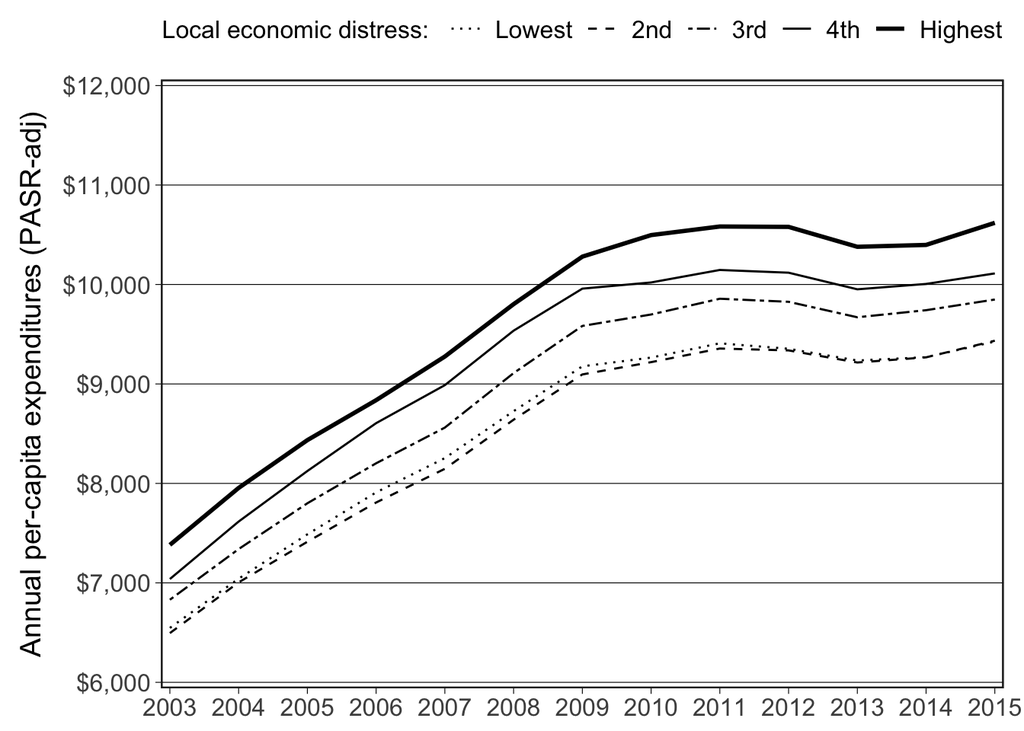

```r
subset <- select(reimb_merged, HSA, Year, DCI.00.Quintile, Enrollees, PASR.Reimb.per.Enrollee)

# plot_hsas(subset, ylab = "A + B reimbursements per enrollee (PASR-adj)")
plot_weighted(subset, ylab = "Annual per-capita expenditures (PASR-adj)",
              legend_title = "Local economic distress: ",
              legend_values = c("Lowest" = "Lowest", "Lower" = "2nd", "Mid" = "3rd", "Higher" = "4th", "Highest" = "Highest"),
              linetype_values = c('dotted', 'dashed', 'twodash', 'solid', 'solid'),
              linesize_values = c(0.5, 0.5, 0.5, 0.5, 1),
              y_lims = c(6000, 12000),
              dollars_not_percent = TRUE)
```

```r
height = 5
aspect_ratio = 1.4
ggsave("/Users/harperwallace/Dropbox/GitHub/howw-dci-medicare-2020/_drafts/_figures/1a.png", height = height, width = height * aspect_ratio, units = "in")

# p + theme(legend.position = 'none')
```

(p-values for ANOVA, year by year)

```r
anova_condensed(subset, 0.001)
```

```
##        Tukey.Pair 2003.p.adj 2004.p.adj 2005.p.adj 2006.p.adj 2007.p.adj
## 1    Lower-Lowest       N.S.       N.S.       N.S.       N.S.       N.S.
## 2      Mid-Lowest      3e-04      4e-04      6e-04       N.S.       N.S.
## 3   Higher-Lowest          0          0          0          0          0
## 4  Highest-Lowest          0          0          0          0          0
## 5       Mid-Lower          0          0          0          0          0
## 6    Higher-Lower          0          0          0          0          0
## 7   Highest-Lower          0          0          0          0          0
## 8      Higher-Mid       N.S.       N.S.      3e-04          0          0
## 9     Highest-Mid          0          0          0          0          0
## 10 Highest-Higher          0          0      7e-04       N.S.       N.S.
##    2008.p.adj 2009.p.adj 2010.p.adj 2011.p.adj 2012.p.adj 2013.p.adj 2014.p.adj
## 1        N.S.       N.S.       N.S.       N.S.       N.S.       N.S.       N.S.
## 2       2e-04      3e-04          0          0          0          0          0
## 3           0          0          0          0          0          0          0
```

[output cut: 18 more lines]

(Ratios of Highest / Lowest reimbursements, year by year)

```r
subset[subset$DCI.00.Quintile == "Lowest" | subset$DCI.00.Quintile == "Highest",] %>%
  group_by(DCI.00.Quintile, Year) %>%
  summarise(wtd.PASR.Reimb.per.Enrollee = weighted.mean(PASR.Reimb.per.Enrollee, Enrollees),
            .groups = 'drop') %>%
  spread(DCI.00.Quintile, wtd.PASR.Reimb.per.Enrollee) %>%
  mutate(Highest.over.Lowest = Highest / Lowest)
```

```
## # A tibble: 13 x 4
##    Year  Lowest Highest Highest.over.Lowest
##    <fct>  <dbl>   <dbl>               <dbl>
##  1 2003   6547.   7382.                1.13
##  2 2004   7042.   7954.                1.13
##  3 2005   7488.   8435.                1.13
##  4 2006   7910.   8837.                1.12
##  5 2007   8255.   9276.                1.12
##  6 2008   8726.   9802.                1.12
##  7 2009   9177.  10280.                1.12
##  8 2010   9265.  10497.                1.13
##  9 2011   9408.  10583.                1.12
## 10 2012   9354.  10579.                1.13
## 11 2013   9235.  10379.                1.12
## 12 2014   9269.  10398.                1.12
## 13 2015   9426.  10620.                1.13
```

By quintile: **2017 DCI**

```r
# subset <- select(reimb_merged, HSA, Year, DCI.17.Quintile, Enrollees, PASR.Reimb.per.Enrollee)

# ratios_summary <- subset[subset$DCI.17.Quintile == "Lowest" | subset$DCI.17.Quintile == "Highest",] %>%
#   group_by(DCI.17.Quintile, Year) %>%
#   summarise(wtd.PASR.Reimb.per.Enrollee = weighted.mean(PASR.Reimb.per.Enrollee, Enrollees),
#             .groups = 'drop') %>%
#   spread(DCI.17.Quintile, wtd.PASR.Reimb.per.Enrollee) %>%
#   mutate(Highest.over.Lowest = Highest / Lowest)
# ratios_summary

# plot_hsas(subset, ylab = "A + B reimbursements per enrollee (PASR-adj)")
# plot_weighted(subset, ylab = "A + B reimbursements per enrollee (PASR-adj)",
#               linetype_values = c('dotted', 'dashed', 'twodash', 'solid', 'solid'),
#               linesize_values = c(0.5, 0.5, 0.5, 0.5, 1),
#               y_lims = c(6000, 11000),
#               dollars_not_percent = TRUE)
```

# Per-capita spending is higher in HSAs with higher DCIs, i.e., in economically worse-off places.

By quintile: **Change in DCI**

```r
# subset <- select(reimb_merged, HSA, Year, D.DCI.Mod.Quintile, Enrollees, PASR.Reimb.per.Enrollee)
#
# plot_hsas(subset, ylab = "A + B reimbursements per enrollee ($, PASR-adj)", quantile_type = "DCI change")
# plot_weighted(subset, ylab = "A + B reimbursements per enrollee ($, PASR-adj)", quantile_type = "DCI change")
```

By cross-quintile: **Change in DCI from 2000**

```r
subset_temp_0 <- reimb_merged[reimb_merged$DCI.00.Quintile == "Lowest",]
subset_0 <- select(subset_temp_0, HSA, Year, DCI.17.HighThree, Enrollees, PASR.Reimb.per.Enrollee)
levels(subset_0$DCI.17.HighThree) <- c("≤ Lower 2017 DCI"="Lowest > Low", "≥ Mid 2017 DCI"="Lowest > High")
colnames(subset_0) <- c("HSA", "Year", "DCI.Change", "Enrollees", "PASR.Reimb.per.Enrollee")

subset_temp_1 <- reimb_merged[reimb_merged$DCI.00.Quintile == "Highest",]
subset_1 <- select(subset_temp_1, HSA, Year, DCI.17.LowThree, Enrollees, PASR.Reimb.per.Enrollee)
levels(subset_1$DCI.17.LowThree) <- c("≤ Mid 2017 DCI"="Highest > Low", "≥ Higher 2017 DCI"="Highest > High")
colnames(subset_1) <- c("HSA", "Year", "DCI.Change", "Enrollees", "PASR.Reimb.per.Enrollee")


subsets_merged <- bind_rows(subset_0, subset_1)
subsets_merged %>%
  group_by(DCI.Change) %>%
  summarise(n = n() / 13,    # divide by number of years to get number HSAs
            .groups = 'drop')
```

```
## # A tibble: 4 x 2
##   DCI.Change         n
##   <fct>          <dbl>
## 1 Lowest > Low     628
## 2 Lowest > High     14
## 3 Highest > Low     39
## 4 Highest > High   603
```

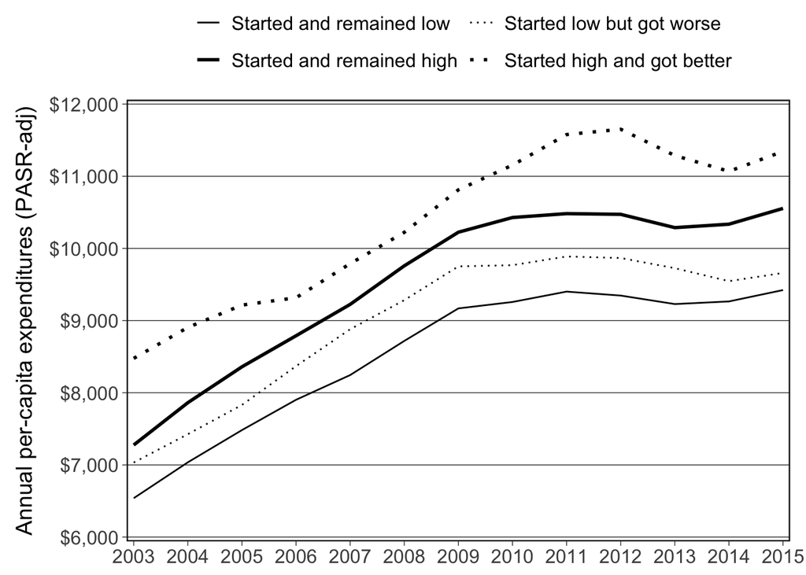

```r
subsets_merged$DCI.Change <- factor(subsets_merged$DCI.Change, levels=c("Lowest > Low", "Lowest > High", "Highest > High", "Highest > Low"))

plot_weighted(subsets_merged, ylab = "Annual per-capita expenditures (PASR-adj)",
              legend_values = c("Started and remained low",
                                "Started low but got worse",
                                "Started and remained high",
                                "Started high and got better"),
              linetype_values = c('solid', 'dotted', 'solid', 'dotted'),
              linesize_values = c(0.5, 0.5, 1, 1),
              y_lims = c(6000, 12000),
              dollars_not_percent = TRUE) +
  guides(linesize=guide_legend(nrow=2,byrow=TRUE)) +
  guides(linetype=guide_legend(nrow=2,byrow=TRUE))
```

```r
height = 5 * 1.075
aspect_ratio = 1.42 / 1.075
ggsave("/Users/harperwallace/Dropbox/GitHub/howw-dci-medicare-2020/_drafts/_figures/1b.png", height = height, width = height * aspect_ratio, units = "in")
```

(p-values for ANOVA, year by year)

```r
anova_condensed(subsets_merged, 0.5)
```

```
##                     Tukey.Pair 2003.p.adj 2004.p.adj 2005.p.adj 2006.p.adj
## 1   Lowest > High-Lowest > Low     0.4467       N.S.       N.S.       N.S.
## 2  Highest > High-Lowest > Low          0          0          0          0
## 3   Highest > Low-Lowest > Low          0          0          0          0
## 4 Highest > High-Lowest > High       N.S.       N.S.       N.S.       N.S.
## 5  Highest > Low-Lowest > High      0.001     0.0018     0.0115     0.1682
## 6 Highest > Low-Highest > High          0          0      0.002     0.1366
##   2007.p.adj 2008.p.adj 2009.p.adj 2010.p.adj 2011.p.adj 2012.p.adj 2013.p.adj
## 1     0.4554       N.S.       N.S.       N.S.       N.S.       N.S.       N.S.
## 2          0          0          0          0          0          0          0
## 3          0          0          0          0          0          0          0
## 4       N.S.       N.S.       N.S.     0.4001     0.4871      0.449     0.4642
## 5     0.2615     0.2605     0.2212     0.0232     0.0027      9e-04     0.0026
## 6     0.1416     0.3234      0.188     0.0257      1e-04          0      1e-04
##   2014.p.adj 2015.p.adj
## 1       N.S.       N.S.
## 2          0          0
## 3          0          0
## 4     0.1692     0.0835
## 5     0.0034      7e-04
## 6       0.01     0.0036
```

```r
# anova_result <- anova_condensed(subsets_merged, 0.5)
# colnames(anova_result) <- c("Tukey.Pair", unique(subset_2$Year))
# print(sapply(anova_result, as.character))
```

By cross-quintile: **Change in DCI from highest 2000**

```r
# plot_hsas(subset_1, ylab = "A + B reimbursements per enrollee (PASR-adj)")
# plot_weighted(subset_1, ylab = "A + B reimbursements per enrollee (PASR-adj)",
#               linetype_values = c('dotted', 'solid'),
#               linesize_values = c(0.5, 1),
#               y_lims = c(6000, 12000),
#               dollars_not_percent = TRUE)
```

# However, per-capita spending is also higher in HSAs that decreased most dramatically (2000–2017), i.e., places that became dramatically economically better-off.

### 6. Age-, sex-, and race-adjusted mortality rates by year

```r
enrollees_mortality <-    medicare_merged %>% select(HSA, starts_with("Enrollees"))
ASR_total_mortality <-    medicare_merged %>% select(HSA, starts_with("ASR.Total"))
ASR_non_hmo_mortality <-  medicare_merged %>% select(HSA, starts_with("ASR.Non.HMO"))

colnames(enrollees_mortality) <-    c("HSA", 2003:2015)
colnames(ASR_total_mortality) <-    c("HSA", 2003:2015)
colnames(ASR_non_hmo_mortality) <-  c("HSA", 2003:2015)

# needed to fix a weird dplylr/reshape2 error per [https://stackoverflow.com/questions/16941111/r-cannot-melt-data-frame]
enrollees_mortality <-    as.data.frame(enrollees_mortality)
ASR_total_mortality <-    as.data.frame(ASR_total_mortality)
ASR_non_hmo_mortality <-  as.data.frame(ASR_non_hmo_mortality)

enrollees_mortality_melted <- melt(enrollees_mortality, id="HSA")
colnames(enrollees_mortality_melted)[(-1:0) + ncol(enrollees_mortality_melted)] <- c("Year", "Enrollees")

ASR_total_mortality_melted <- melt(ASR_total_mortality, id="HSA")
colnames(ASR_total_mortality_melted)[(-1:0) + ncol(ASR_total_mortality_melted)] <- c("Year", "ASR.Total.Mortality")

ASR_non_hmo_mortality_melted <- melt(ASR_non_hmo_mortality, id="HSA")
colnames(ASR_non_hmo_mortality_melted)[(-1:0) + ncol(ASR_non_hmo_mortality_melted)] <- c("Year", "ASR.Non.HMO.Mortality")

mortality_merged_temp_0 <-  left_join(ASR_non_hmo_mortality_melted, ASR_total_mortality_melted, by=c("HSA", "Year"))
mortality_merged_temp_1 <-  left_join(enrollees_mortality_melted, mortality_merged_temp_0, by=c("HSA", "Year"))
mortality_merged_temp_2 <-  left_join(dci_quantile_crossover, mortality_merged_temp_1, by="HSA")

# remove any incomplete cases
mortality_merged <-         mortality_merged_temp_2[complete.cases(mortality_merged_temp_2),]

# total HSAs used in mortality analysis (total entries divided by 13 years)
mortality_merged %>% summarise(n = n() / 13)
```

```
## # A tibble: 1 x 1
##       n
##   <dbl>
## 1  3212
```

#### Plot non-HMO mortality

By secondile: **Change in DCI**

```r
# subset <- select(mortality_merged, HSA, Year, D.DCI.Mod.Secondile, Enrollees, ASR.Non.HMO.Mortality)
#
# plot_hsas(subset, ylab = "Non-HMO mortality (%, ASR-adj)", quantile_type = "DCI change")
# plot_weighted(subset, ylab = "Non-HMO mortality (%, ASR-adj)", quantile_type = "DCI change", inset = FALSE)
```

By tertile: **Change in DCI**

```r
# subset <- select(mortality_merged, HSA, Year, D.DCI.Mod.Tertile, Enrollees, ASR.Non.HMO.Mortality)
#
# plot_hsas(subset, ylab = "Non-HMO mortality (%, ASR-adj)", quantile_type = "DCI change")
# plot_weighted(subset, ylab = "Non-HMO mortality (%, ASR-adj)", quantile_type = "DCI change", inset = FALSE)
```

By quintile: **2000 DCI**

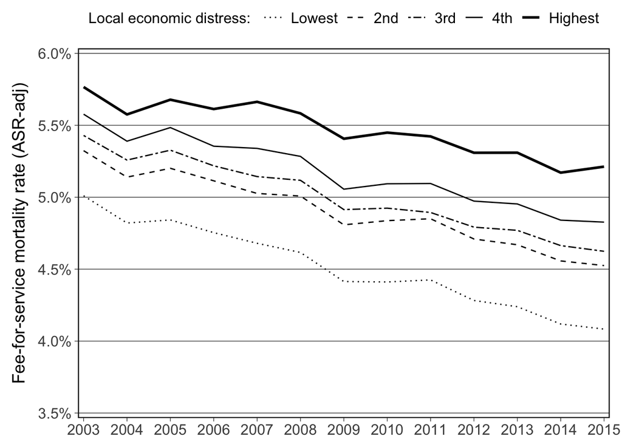

```r
subset <- select(mortality_merged, HSA, Year, DCI.00.Quintile, Enrollees, ASR.Non.HMO.Mortality)

# plot_hsas(subset, ylab = "Non-HMO mortality (ASR-adj)")
plot_weighted(subset, ylab = "Fee-for-service mortality rate (ASR-adj)",
              legend_title = "Local economic distress: ",
              legend_values = c("Lowest" = "Lowest", "Lower" = "2nd", "Mid" = "3rd", "Higher" = "4th", "Highest" = "Highest"),
              linetype_values = c('dotted', 'dashed', 'twodash', 'solid', 'solid'),
              linesize_values = c(0.5, 0.5, 0.5, 0.5, 1),
              y_lims = c(3.5, 6),
              dollars_not_percent = FALSE)
```

```r
height = 5
aspect_ratio = 1.4
ggsave("/Users/harperwallace/Dropbox/GitHub/howw-dci-medicare-2020/_drafts/_figures/2a.png", height = height, width = height * aspect_ratio, units = "in")

# p + theme(legend.position = 'none')
```

(p-values for ANOVA, year by year)

```r
anova_condensed(subset, 0.001)
```

```
##        Tukey.Pair 2003.p.adj 2004.p.adj 2005.p.adj 2006.p.adj 2007.p.adj
## 1    Lower-Lowest          0          0          0          0          0
## 2      Mid-Lowest          0          0          0          0          0
## 3   Higher-Lowest          0          0          0          0          0
## 4  Highest-Lowest          0          0          0          0          0
## 5       Mid-Lower       N.S.       N.S.       N.S.       N.S.       N.S.
## 6    Higher-Lower          0          0          0          0          0
## 7   Highest-Lower          0          0          0          0          0
## 8      Higher-Mid       N.S.       N.S.       N.S.       N.S.          0
## 9     Highest-Mid          0          0          0          0          0
## 10 Highest-Higher          0          0      1e-04          0          0
##    2008.p.adj 2009.p.adj 2010.p.adj 2011.p.adj 2012.p.adj 2013.p.adj 2014.p.adj
## 1           0          0          0          0          0          0          0
## 2           0          0          0          0          0          0          0
## 3           0          0          0          0          0          0          0
```

[output cut: 18 more lines]

```r
subset[subset$DCI.00.Quintile == "Lowest" | subset$DCI.00.Quintile == "Highest",] %>%
  group_by(DCI.00.Quintile, Year) %>%
  summarise(wtd.ASR.Non.HMO.Mortality = weighted.mean(ASR.Non.HMO.Mortality, Enrollees),
            .groups = 'drop') %>%
  spread(DCI.00.Quintile, wtd.ASR.Non.HMO.Mortality) %>%
  mutate(Highest.over.Lowest = Highest / Lowest)
```

```
## # A tibble: 13 x 4
##    Year  Lowest Highest Highest.over.Lowest
##    <fct>  <dbl>   <dbl>               <dbl>
##  1 2003    5.01    5.77                1.15
##  2 2004    4.82    5.58                1.16
##  3 2005    4.84    5.68                1.17
##  4 2006    4.75    5.61                1.18
##  5 2007    4.68    5.66                1.21
##  6 2008    4.62    5.58                1.21
##  7 2009    4.41    5.41                1.22
##  8 2010    4.41    5.45                1.24
##  9 2011    4.43    5.42                1.23
## 10 2012    4.28    5.31                1.24
## 11 2013    4.24    5.31                1.25
## 12 2014    4.12    5.17                1.26
## 13 2015    4.08    5.21                1.28
```

By quintile: **2017 DCI**

```r
# subset <- select(mortality_merged, HSA, Year, DCI.17.Quintile, Enrollees, ASR.Non.HMO.Mortality)
#
# ratios_summary <- subset[subset$DCI.17.Quintile == "Lowest" | subset$DCI.17.Quintile == "Highest",] %>%
#   group_by(DCI.17.Quintile, Year) %>%
#   summarise(wtd.ASR.Non.HMO.Mortality = weighted.mean(ASR.Non.HMO.Mortality, Enrollees),
#             .groups = 'drop') %>%
#   spread(DCI.17.Quintile, wtd.ASR.Non.HMO.Mortality) %>%
#   mutate(Highest.over.Lowest = Highest / Lowest)
# ratios_summary
#
# plot_hsas(subset, ylab = "Non-HMO mortality (ASR-adj)")
# plot_weighted(subset, ylab = "Non-HMO mortality (ASR-adj)",
#               linetype_values = c('dotted', 'dashed', 'twodash', 'solid', 'solid'),
#               linesize_values = c(0.5, 0.5, 0.5, 0.5, 1),
#               y_lims = c(3.5, 6),
#               dollars_not_percent = FALSE)
```